# Tree Methods Project

# Tree Methods Project

For this project we will be exploring the use of tree methods to classify schools as Private or Public based off their features. Let’s start by getting the data which is included in the ISLR library, the College data frame. A data frame with 777 observations on the following 18 variables.

- Private A factor with levels No and Yes indicating private or public university
- Apps Number of applications received
- Accept Number of applications accepted
- Enroll Number of new students enrolled
- Top10perc Pct. new students from top 10% of H.S. class
- Top25perc Pct. new students from top 25% of H.S. class
- F.Undergrad Number of fulltime undergraduates
- P.Undergrad Number of parttime undergraduates
- Outstate Out-of-state tuition
- Room.Board Room and board costs
- Books Estimated book costs
- Personal Estimated personal spending
- PhD Pct. of faculty with Ph.D.’s
- Terminal Pct. of faculty with terminal degree
- S.F.Ratio Student/faculty ratio
- perc.alumni Pct. alumni who donate
- Expend Instructional expenditure per student
- Grad.Rate Graduation rate

## Get the Data

### Call the ISLR library and check the head of College (a built-in data frame with ISLR, use data() to check this.) Then reassign College to a dataframe called df

```r
remove(list = ls())
library(ISLR)
head(College)
```

|  | Private | Apps | Accept | Enroll | Top10perc | Top25perc | F.Undergrad | P.Undergrad | Outstate | Room.Board | Books | Personal | PhD | Terminal | S.F.Ratio | perc.alumni | Expend | Grad.Rate |
| --- | --- | --- | --- | --- | --- | --- | --- | --- | --- | --- | --- | --- | --- | --- | --- | --- | --- | --- |
| Abilene Christian University | Yes | 1660 | 1232 | 721 | 23 | 52 | 2885 | 537 | 7440 | 3300 | 450 | 2200 | 70 | 78 | 18.1 | 12 | 7041 | 60 |
| Adelphi University | Yes | 2186 | 1924 | 512 | 16 | 29 | 2683 | 1227 | 12280 | 6450 | 750 | 1500 | 29 | 30 | 12.2 | 16 | 10527 | 56 |
| Adrian College | Yes | 1428 | 1097 | 336 | 22 | 50 | 1036 | 99 | 11250 | 3750 | 400 | 1165 | 53 | 66 | 12.9 | 30 | 8735 | 54 |
| Agnes Scott College | Yes | 417 | 349 | 137 | 60 | 89 | 510 | 63 | 12960 | 5450 | 450 | 875 | 92 | 97 | 7.7 | 37 | 19016 | 59 |
| Alaska Pacific University | Yes | 193 | 146 | 55 | 16 | 44 | 249 | 869 | 7560 | 4120 | 800 | 1500 | 76 | 72 | 11.9 | 2 | 10922 | 15 |
| Albertson College | Yes | 587 | 479 | 158 | 38 | 62 | 678 | 41 | 13500 | 3335 | 500 | 675 | 67 | 73 | 9.4 | 11 | 9727 | 55 |

```r
df <- data.frame(College)
head(df)
```

|  | Private | Apps | Accept | Enroll | Top10perc | Top25perc | F.Undergrad | P.Undergrad | Outstate | Room.Board | Books | Personal | PhD | Terminal | S.F.Ratio | perc.alumni | Expend | Grad.Rate |
| --- | --- | --- | --- | --- | --- | --- | --- | --- | --- | --- | --- | --- | --- | --- | --- | --- | --- | --- |
| Abilene Christian University | Yes | 1660 | 1232 | 721 | 23 | 52 | 2885 | 537 | 7440 | 3300 | 450 | 2200 | 70 | 78 | 18.1 | 12 | 7041 | 60 |
| Adelphi University | Yes | 2186 | 1924 | 512 | 16 | 29 | 2683 | 1227 | 12280 | 6450 | 750 | 1500 | 29 | 30 | 12.2 | 16 | 10527 | 56 |
| Adrian College | Yes | 1428 | 1097 | 336 | 22 | 50 | 1036 | 99 | 11250 | 3750 | 400 | 1165 | 53 | 66 | 12.9 | 30 | 8735 | 54 |
| Agnes Scott College | Yes | 417 | 349 | 137 | 60 | 89 | 510 | 63 | 12960 | 5450 | 450 | 875 | 92 | 97 | 7.7 | 37 | 19016 | 59 |
| Alaska Pacific University | Yes | 193 | 146 | 55 | 16 | 44 | 249 | 869 | 7560 | 4120 | 800 | 1500 | 76 | 72 | 11.9 | 2 | 10922 | 15 |
| Albertson College | Yes | 587 | 479 | 158 | 38 | 62 | 678 | 41 | 13500 | 3335 | 500 | 675 | 67 | 73 | 9.4 | 11 | 9727 | 55 |

## EDA

Let’s explore the data!

### Create a scatterplot of Grad.Rate versus Room.Board, colored by the Private column.

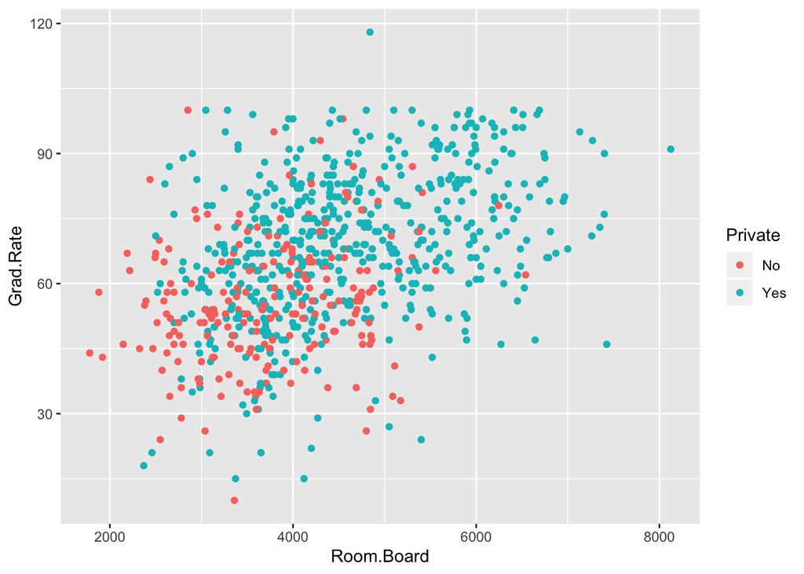

```r
library(ggplot2)
ggplot(data = df, aes(Room.Board, Grad.Rate)) + geom_point(aes(color = Private))
```

### Create a histogram of full time undergrad students, color by Private.

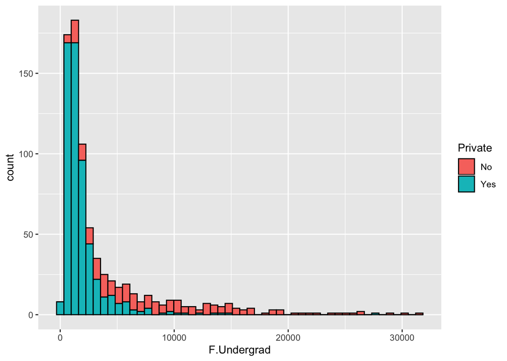

```r
ggplot(data = df, aes(F.Undergrad)) + geom_histogram(aes(fill = Private),color = 'black', bins = 50)
```

### Create a histogram of Grad.Rate colored by Private. You should see something odd here.

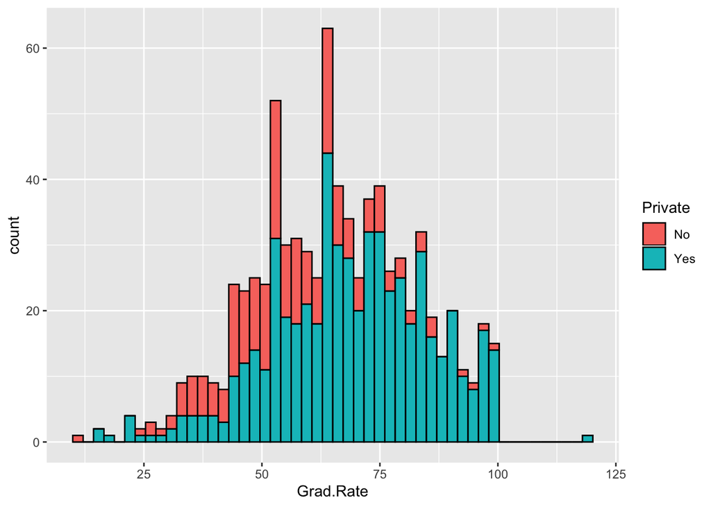

```r
ggplot(data = df, aes(Grad.Rate)) + geom_histogram(aes(fill = Private),color = 'black', bins = 50)
```

### What college had a Graduation Rate of above 100% ?

```r
subset(df,Grad.Rate > 100)
```

|  | Private | Apps | Accept | Enroll | Top10perc | Top25perc | F.Undergrad | P.Undergrad | Outstate | Room.Board | Books | Personal | PhD | Terminal | S.F.Ratio | perc.alumni | Expend | Grad.Rate |
| --- | --- | --- | --- | --- | --- | --- | --- | --- | --- | --- | --- | --- | --- | --- | --- | --- | --- | --- |
| Cazenovia College | Yes | 3847 | 3433 | 527 | 9 | 35 | 1010 | 12 | 9384 | 4840 | 600 | 500 | 22 | 47 | 14.3 | 20 | 7697 | 118 |

### Change that college’s grad rate to 100%

```r
df['Cazenovia College', 'Grad.Rate'] <- 100
```

## Train Test Split

### Split your data into training and testing sets 70/30. Use the caTools library to do this.

```r
set.seed(101)
library(caTools)

sample <- caTools::sample.split(df$Private, SplitRatio = 0.70)
train <- subset(df, sample == TRUE)
test <- subset(df, sample == FALSE)
```

## Decision Tree

### Use the rpart library to build a decision tree to predict whether or not a school is Private. Remember to only build your tree off the training data.

```r
library(rpart)
tree.model <- rpart(Private~., train, method = 'class')
```

### Use predict() to predict the Private label on the test data.

```r
predict.private <- predict(object = tree.model, test)
```

### Check the Head of the predicted values. You should notice that you actually have two columns with the probabilities.

```r
head(predict.private)
```

```
##                                                  No       Yes
## Adrian College                          0.003311258 0.9966887
## Alfred University                       0.003311258 0.9966887
## Allegheny College                       0.003311258 0.9966887
## Allentown Coll. of St. Francis de Sales 0.003311258 0.9966887
## Alma College                            0.003311258 0.9966887
## Amherst College                         0.003311258 0.9966887
```

### Turn these two columns into one column to match the original Yes/No Label for a Private column.

```r
predict.private <- as.data.frame(predict.private)
# Lots of ways to do this
joiner <- function(x){
    if (x>=0.5){
        return('Yes')
    }else{
        return("No")
    }
}
predict.private$Private <- sapply(predict.private$Yes,joiner)
head(predict.private)
```

|  | No | Yes | Private |
| --- | --- | --- | --- |
| Adrian College | 0.003311258 | 0.9966887 | Yes |
| Alfred University | 0.003311258 | 0.9966887 | Yes |
| Allegheny College | 0.003311258 | 0.9966887 | Yes |
| Allentown Coll. of St. Francis de Sales | 0.003311258 | 0.9966887 | Yes |
| Alma College | 0.003311258 | 0.9966887 | Yes |
| Amherst College | 0.003311258 | 0.9966887 | Yes |

### Now use table() to create a confusion matrix of your tree model.

```r
table(predict.private$Private, test$Private)
```

```
##
##        No Yes
##   No   57   9
##   Yes   7 160
```

### Use the rpart.plot library and the prp() function to plot out your tree model.

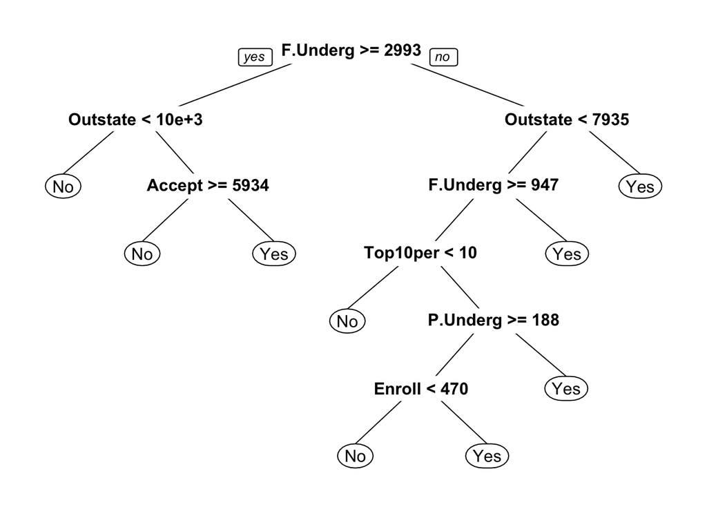

```r
library(rpart.plot)
prp(tree.model)
```

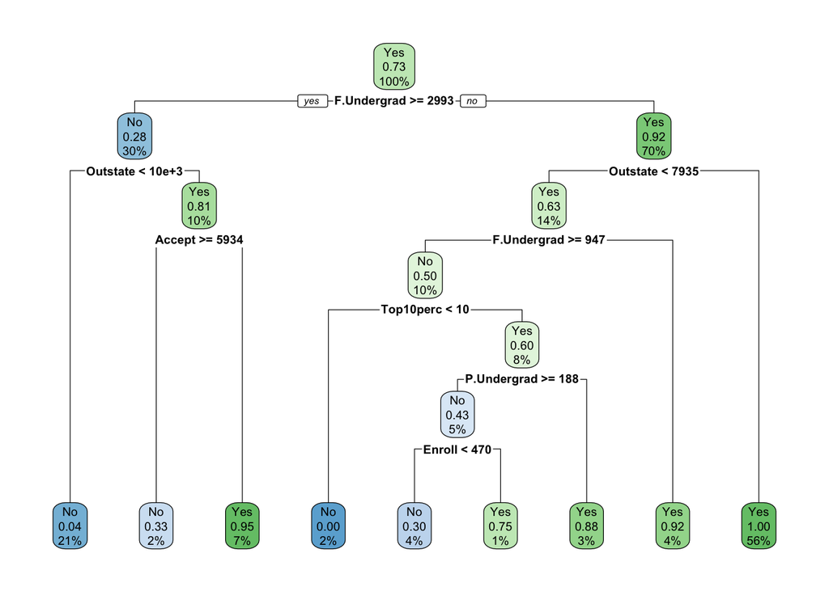

```r
rpart.plot(tree.model)
```

## Random Forest

Now let’s build out a random forest model!

### Call the randomForest package library

```r
library(randomForest)
```

### Now use randomForest() to build out a model to predict Private class. Add importance=TRUE as a parameter in the model. (Use help(randomForest) to find out what this does.

```r
rf.model <- randomForest(Private ~ . , data = train,importance = TRUE)
```

### What was your model’s confusion matrix on its own training set? Use model$confusion.

```r
rf.model$confusion
```

```
##      No Yes class.error
## No  125  23  0.15540541
## Yes  10 386  0.02525253
```

### Grab the feature importance with model$importance. Refer to the reading for more info on what Gini[1] means.[2]

```r
rf.model$importance
```

```
##                       No          Yes MeanDecreaseAccuracy MeanDecreaseGini
## Apps        0.0299975940 1.581643e-02         0.0195732992         9.093474
## Accept      0.0265169723 1.359972e-02         0.0169830344        11.252450
## Enroll      0.0360668986 2.852824e-02         0.0305094654        22.810173
## Top10perc   0.0094902570 5.700969e-03         0.0067307985         5.535670
## Top25perc   0.0049996299 2.891095e-03         0.0035060616         4.568160
## F.Undergrad 0.1591184093 6.945790e-02         0.0937286273        38.842710
## P.Undergrad 0.0436610506 7.334280e-03         0.0170748529        16.934128
## Outstate    0.1456738704 6.461743e-02         0.0865178571        42.669650
## Room.Board  0.0147668601 1.439793e-02         0.0144179025        10.414502
## Books       0.0007389787 8.914367e-05         0.0002868557         2.203342
## Personal    0.0029767520 8.632755e-04         0.0014664250         3.710353
## PhD         0.0086149598 5.320894e-03         0.0061979645         4.624097
## Terminal    0.0044437470 6.488106e-03         0.0059953078         4.524290
## S.F.Ratio   0.0302010312 8.307646e-03         0.0142830244        16.017899
## perc.alumni 0.0166161199 3.455476e-03         0.0071053253         5.280970
## Expend      0.0235732631 1.270668e-02         0.0155385819         9.860188
## Grad.Rate   0.0149251559 5.575670e-03         0.0080482732         6.520158
```

## Predictions

### Now use your random forest model to predict on your test set!

```r
p <- predict(rf.model,test)
table(p,test$Private)
```

```
##
## p      No Yes
##   No   57   6
##   Yes   7 163
```

#### It should have performed better than just a single tree, how much better depends on whether you are emasuring recall, precision, or accuracy as the most important measure of the model.